# Accounting for dividends gains: stock portfolio real performance calculator

## Motivation

A brokerage account normally allows to quickly check the unrealized capital gain/loss of the portfolio, that is, the money the investor would gain/lose if he sold his stocks at that moment. However, this value doesn't take into account the dividends a company has paid throughout the time the investor has held the stock. Specifically, the potential gain/loss doesn't account for the reinvested dividends or the dividends held in cash. The following simplified example further illustrates the problematic.

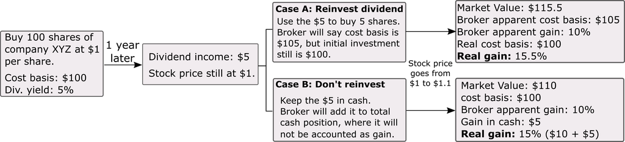

```python
import os
#Go to image's location
path = "D:\Personal\Inversion"
os.chdir(path)

from IPython.display import Image
Image(filename='Div_explanation.png')
```

Thus, the investor may think he has a 10% gain on his initial investment but, in reality, he has around 15% gain, accounting for dividends.

Or

The investor is aware that his real gain is not 10%, but does not have quick/easy access to his real gain/loss on an specific dividend stock or overall portfolio.

**Final note:** This simplified example does not account for Tax reduction on the gains. Then again, the unrealized capital gain shown in the brokerage account does not account for this reduction either. As Tax deduction depends on the personal situation of each investor, the following calculator will focus on gross profit.

## Performance calculator

In this notebook, a tool for automatically calculating the real performance of a stock portfolio is developed. Specifically, this tool aims to account for both the capital gain/loss and the dividends the company has paid to the investor.

To do so, the following steps are done:

- **Data preparation:** The csv files from the brokerage account are imported, and the data of each database is prepared for data analysis.
- **Data transformation:** The different databases are used to account for dividend gains and compute the real gain/loss of each stock investment. The results are merged into a final database.
- **Data visualization:** The real performance of stocks is visually compared to the gain/loss indicated by the brokerage account. The importance of accounting for dividends gain is reflected.

All of the steps were done with Python and its libraries.

# Data exploration and transformation

```python
#Import required libraries
import pandas as pd
import numpy as np
import matplotlib.pyplot as plt
import seaborn as sns
```

Now let's import the csv databases of importance. In particular:

- Positions file: Contains the current holdings of the portfolio.
- Transactions file: Contains the history of the transactions made in the account.

These files should be readily available to download on the personal brokerage account of each investor. For this work, we'll use the files format provided by a Charles Schwab brokerage account, as they are one of the largest brokerage firms. Nevertheless, this tool is applicable to every brokerage firm, with minor adjustements.

```python
pos = pd.read_csv(r'D:\Personal\Inversion\pos.csv')
trans = pd.read_csv(r'D:\Personal\Inversion\trans.csv')
```

Let's start with analyzing the positions database

```python
#First, a quick glampse
pos.head()
```

|  | Symbol | Description | Quantity | Price | Price Change $ | Price Change % | Market Value | Day Change $ | Day Change % | Cost Basis | ... | Last Dividend | Ex-Dividend Date | P/E Ratio | 52 Week Low | 52 Week High | Volume | Intrinsic Value | In The Money | Security Type | Unnamed: 25 |
| --- | --- | --- | --- | --- | --- | --- | --- | --- | --- | --- | --- | --- | --- | --- | --- | --- | --- | --- | --- | --- | --- |
| 0 | T | A T & T INC | 27.0634 | $29.96 | -$0.08 | -0.27% | $810.82 | -$2.17 | -0.27% | $792.44 | ... | $0.52 | 4/8/2021 | -39.95 | $26.35 | $33.24 | 10,446 | -- | -- | Equity | -- |
| 1 | CVS | CVS HEALTH CORP | 7.174 | $74.46 | $0.39 | +0.53% | $534.18 | $2.80 | +0.53% | $433.33 | ... | $0.50 | 4/22/2021 | 13.61 | $55.36 | $77.23 | 125 | -- | -- | Equity | -- |
| 2 | DBX | DROPBOX INC | 18 | $26.05 | -$0.94 | -3.48% | $468.9 | -$16.92 | -3.48% | $405.28 | ... | -- | -- | -42.02 | $17.66 | $28.33 | 90 | -- | -- | Equity | -- |
| 3 | TTCF | TATTOOED CHEF INC CLASS A | 15 | $18.97 | -$0.22 | -1.15% | $284.55 | -$3.30 | -1.15% | $303.95 | ... | -- | -- | 11.22 | $10.33 | $28.64 | 407 | -- | -- | Equity | -- |
| 4 | SCHV | SCHWAB US LARGE CAP VALUE ETF | 5.0302 | $66.60 | $0.07 | +0.11% | $335.01 | $0.35 | +0.1% | $273.39 | ... | $0.29 | 3/24/2021 | -- | $45.16 | $66.64 | -- | -- | -- | ETFs & Closed End Funds | -- |

5 rows × 26 columns

### Remove columns

There are various columns we won't need. Let's check and drop them

```python
pos.columns
```

```
Index(['Symbol', 'Description', 'Quantity', 'Price', 'Price Change $',
       'Price Change %', 'Market Value', 'Day Change $', 'Day Change %',
       'Cost Basis', 'Gain/Loss $', 'Gain/Loss %', 'Reinvest Dividends?',
       'Capital Gains?', '% Of Account', 'Dividend Yield', 'Last Dividend',
       'Ex-Dividend Date', 'P/E Ratio', '52 Week Low', '52 Week High',
       'Volume', 'Intrinsic Value', 'In The Money', 'Security Type',
       'Unnamed: 25'],
      dtype='object')
```

```python
pos = pos.drop(['Day Change $','Day Change %','Price Change $','Price Change %','Reinvest Dividends?',
                'Capital Gains?','Volume','Intrinsic Value','In The Money','Unnamed: 25','Last Dividend',
                'Ex-Dividend Date','P/E Ratio','52 Week Low', '52 Week High'], axis = 1)
pos
```

|  | Symbol | Description | Quantity | Price | Market Value | Cost Basis | Gain/Loss $ | Gain/Loss % | % Of Account | Dividend Yield | Security Type |
| --- | --- | --- | --- | --- | --- | --- | --- | --- | --- | --- | --- |
| 0 | T | A T & T INC | 27.0634 | $29.96 | $810.82 | $792.44 | $18.38 | +2.32% | 20.31% | +6.9% | Equity |
| 1 | CVS | CVS HEALTH CORP | 7.174 | $74.46 | $534.18 | $433.33 | $100.85 | +23.27% | 13.38% | +2.7% | Equity |
| 2 | DBX | DROPBOX INC | 18 | $26.05 | $468.9 | $405.28 | $63.62 | +15.7% | 11.74% | -- | Equity |
| 3 | TTCF | TATTOOED CHEF INC CLASS A | 15 | $18.97 | $284.55 | $303.95 | -$19.40 | -6.38% | 7.13% | -- | Equity |
| 4 | SCHV | SCHWAB US LARGE CAP VALUE ETF | 5.0302 | $66.60 | $335.01 | $273.39 | $61.62 | +22.54% | 8.39% | +2.5% | ETFs & Closed End Funds |
| 5 | SCHA | SCHWAB US SMALL CAP ETF | 6 | $100.83 | $604.98 | $427.91 | $177.07 | +41.38% | 15.15% | +0.9% | ETFs & Closed End Funds |
| 6 | Cash & Cash Investments | -- | -- | -- | $954.33 | -- | -- | -- | 23.9% | -- | Cash and Money Market |
| 7 | Account Total | -- | -- | -- | $3992.77 | $2,636.30 | $402.14 | +15.25% | 100.0% | -- | -- |

### Text mining

Much cleaner! Now, let's do some text mining and make sure we have numeric values in each column of interest, instead of strings.

```python
#Replace "--" string with numpy nans, to be able to make operations on columns.
pos.replace('--',np.nan, inplace =True)
#Group columns into dollar and percentage values
Dolcol=['Price','Market Value','Cost Basis', 'Gain/Loss $']
Percol=['Gain/Loss %','% Of Account','Dividend Yield']
Numcol=['Quantity']
#Delete symbols and convert to numeric values
pos[Dolcol] = pos[Dolcol].replace('[\$,]', '', regex=True).astype(float)
pos[Percol] = pos[Percol].replace('[\$%,]', '', regex=True).astype(float)
pos[Numcol] = pos[Numcol].astype(float)
pos
```

|  | Symbol | Description | Quantity | Price | Market Value | Cost Basis | Gain/Loss $ | Gain/Loss % | % Of Account | Dividend Yield | Security Type |
| --- | --- | --- | --- | --- | --- | --- | --- | --- | --- | --- | --- |
| 0 | T | A T & T INC | 27.0634 | 29.96 | 810.82 | 792.44 | 18.38 | 2.32 | 20.31 | 6.9 | Equity |
| 1 | CVS | CVS HEALTH CORP | 7.1740 | 74.46 | 534.18 | 433.33 | 100.85 | 23.27 | 13.38 | 2.7 | Equity |
| 2 | DBX | DROPBOX INC | 18.0000 | 26.05 | 468.90 | 405.28 | 63.62 | 15.70 | 11.74 | NaN | Equity |
| 3 | TTCF | TATTOOED CHEF INC CLASS A | 15.0000 | 18.97 | 284.55 | 303.95 | -19.40 | -6.38 | 7.13 | NaN | Equity |
| 4 | SCHV | SCHWAB US LARGE CAP VALUE ETF | 5.0302 | 66.60 | 335.01 | 273.39 | 61.62 | 22.54 | 8.39 | 2.5 | ETFs & Closed End Funds |
| 5 | SCHA | SCHWAB US SMALL CAP ETF | 6.0000 | 100.83 | 604.98 | 427.91 | 177.07 | 41.38 | 15.15 | 0.9 | ETFs & Closed End Funds |
| 6 | Cash & Cash Investments | NaN | NaN | NaN | 954.33 | NaN | NaN | NaN | 23.90 | NaN | Cash and Money Market |
| 7 | Account Total | NaN | NaN | NaN | 3992.77 | 2636.30 | 402.14 | 15.25 | 100.00 | NaN | NaN |

After preparing the dataset, we can have a look at the portfolio composition:

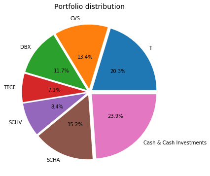

```python
pie, ax = plt.subplots(figsize=[10,6])
labels = pos['Symbol'][:-1]
plt.pie(x=pos['% Of Account'][:-1], autopct="%.1f%%", explode=[0.05]*7, labels=labels, pctdistance=0.5)
plt.title("Portfolio distribution", fontsize=14);
#pie.savefig("DeliveryPieChart.png")
```

## Looking for Dividends

Now that the positions data is set, let's check on the transaction history file.

```python
trans.head(10)
```

|  | Date | Action | Symbol | Description | Quantity | Price | Fees & Comm | Amount | Unnamed: 8 |
| --- | --- | --- | --- | --- | --- | --- | --- | --- | --- |
| 0 | 04/09/2021 | Sell | EXC | EXELON CORP | 0.0665 | $45.00 | NaN | $2.99 | NaN |
| 1 | 04/09/2021 | Sell | EXC | EXELON CORP | 2.0000 | $45.00 | NaN | $90.00 | NaN |
| 2 | 04/01/2021 | NRA Tax Adj | PPL | PPL CORP | NaN | NaN | NaN | -$0.20 | NaN |
| 3 | 04/01/2021 | Qualified Dividend | PPL | PPL CORP | NaN | NaN | NaN | $1.31 | NaN |
| 4 | 03/30/2021 | Buy | TTCF | TATTOOED CHEF INC CLASS A | 1.0000 | $18.35 | NaN | -$18.35 | NaN |
| 5 | 03/29/2021 | NRA Tax Adj | SCHA | SCHWAB US SMALL CAP ETF | NaN | NaN | NaN | -$0.20 | NaN |
| 6 | 03/29/2021 | Cash Dividend | SCHA | SCHWAB US SMALL CAP ETF | NaN | NaN | NaN | $1.30 | NaN |
| 7 | 03/29/2021 | NRA Tax Adj | SCHV | SCHWAB US LARGE CAP VALUE ETF | NaN | NaN | NaN | -$0.22 | NaN |
| 8 | 03/29/2021 | Cash Dividend | SCHV | SCHWAB US LARGE CAP VALUE ETF | NaN | NaN | NaN | $1.46 | NaN |
| 9 | 03/25/2021 | Buy | TTCF | TATTOOED CHEF INC CLASS A | 1.0000 | $19.00 | NaN | -$19.00 | NaN |

For the purpose of this project, we are only interested on dividends related transactions. Thus, we can filter through the "Action" column, as we are not interested in the actions regarding buy/sell of stocks.

```python
trans['Action'].unique()
```

```
array(['Sell', 'NRA Tax Adj', 'Qualified Dividend', 'Buy',
       'Cash Dividend', 'Reinvest Shares', 'Qual Div Reinvest',
       'Reinvest Dividend'], dtype=object)
```

```python
#Let's remove the buy/sell actions
div = trans[~trans["Action"].isin(['Buy','Sell'])]
```

Quick nomenclature:

- **Cash dividend / Qual Div Reinvest / Qualified Dividend:** Total Dividends payments received from the company, subject to Tax deduction.
- **NRA Tax Adj:** Tax amount deducted from dividends payment.
- **Reinvest Shares:** Dividend income (after tax deduction) reinvested in the company.

```python
#Temporarily disable chaining warning since the one emitted with the following 'groupby' command is a false positive
#More info at: https://stackoverflow.com/questions/45109257/pandas-operations-using-groupby-yield-settingwithcopywarning
pd.options.mode.chained_assignment = None
```

```python
#Change cell format to numeric, and group by action and symbol
div['Amount'] = div['Amount'].replace('[\$,]', '', regex=True).astype(float)
div = div.groupby(['Action',"Symbol"])['Amount'].sum().reset_index()
div.head(20)
```

|  | Action | Symbol | Amount |
| --- | --- | --- | --- |
| 0 | Cash Dividend | SCHA | 10.75 |
| 1 | Cash Dividend | SCHV | 15.71 |
| 2 | NRA Tax Adj | BAC | -0.42 |
| 3 | NRA Tax Adj | C | -0.62 |
| 4 | NRA Tax Adj | CVS | -1.97 |
| 5 | NRA Tax Adj | EMR | -0.15 |
| 6 | NRA Tax Adj | EXC | -0.48 |
| 7 | NRA Tax Adj | FL | -0.30 |
| 8 | NRA Tax Adj | GE | -0.14 |
| 9 | NRA Tax Adj | HPE | -0.80 |
| 10 | NRA Tax Adj | M | -0.28 |
| 11 | NRA Tax Adj | PPL | -0.97 |
| 12 | NRA Tax Adj | SCHA | -1.62 |
| 13 | NRA Tax Adj | SCHV | -2.67 |
| 14 | NRA Tax Adj | T | -5.40 |
| 15 | Qual Div Reinvest | BAC | 2.72 |
| 16 | Qual Div Reinvest | C | 4.14 |
| 17 | Qual Div Reinvest | CVS | 13.13 |
| 18 | Qual Div Reinvest | EXC | 3.10 |
| 19 | Qual Div Reinvest | FL | 2.00 |

```python
pd.options.mode.chained_assignment = 'warn'
```

#### Dividends payments received

```python
#Dataframe with the total amount of dividends received

divtot = div[~div['Action'].str.contains('Reinvest Shares|NRA Tax Adj')]
divtot = divtot.groupby('Symbol')['Amount'].sum().reset_index()
divtot.rename(columns={'Amount':'Dividends'},inplace = True)
divtot
```

|  | Symbol | Dividends |
| --- | --- | --- |
| 0 | BAC | 2.72 |
| 1 | C | 4.14 |
| 2 | CVS | 13.13 |
| 3 | DHT | 29.07 |
| 4 | EMR | 1.00 |
| 5 | EXC | 3.10 |
| 6 | FL | 2.00 |
| 7 | GE | 0.92 |
| 8 | HPE | 5.36 |
| 9 | M | 1.89 |
| 10 | PPL | 6.40 |
| 11 | SCHA | 10.75 |
| 12 | SCHV | 17.72 |
| 13 | T | 35.99 |

#### Tax deduction

```python
#Dataframe with the tax deduction
divtax = div[div['Action'] == 'NRA Tax Adj'].reset_index(drop=True)
divtax = divtax.groupby('Symbol')['Amount'].sum().reset_index()
divtax.rename(columns={'Amount':'Div. tax deduction'},inplace = True)
divtax
```

|  | Symbol | Div. tax deduction |
| --- | --- | --- |
| 0 | BAC | -0.42 |
| 1 | C | -0.62 |
| 2 | CVS | -1.97 |
| 3 | EMR | -0.15 |
| 4 | EXC | -0.48 |
| 5 | FL | -0.30 |
| 6 | GE | -0.14 |
| 7 | HPE | -0.80 |
| 8 | M | -0.28 |
| 9 | PPL | -0.97 |
| 10 | SCHA | -1.62 |
| 11 | SCHV | -2.67 |
| 12 | T | -5.40 |

#### Dividends reinvested

```python
#Dataframe with the amount of dividends reinvested
divreinv = div[div['Action'] == 'Reinvest Shares'].reset_index(drop=True)
divreinv = divreinv.groupby('Symbol')['Amount'].sum().reset_index()
divreinv.rename(columns={'Amount':'Reinvested'},inplace = True)
divreinv
```

|  | Symbol | Reinvested |
| --- | --- | --- |
| 0 | BAC | -2.30 |
| 1 | C | -3.52 |
| 2 | CVS | -11.16 |
| 3 | DHT | -29.07 |
| 4 | EXC | -2.62 |
| 5 | FL | -1.70 |
| 6 | GE | -0.78 |
| 7 | HPE | -3.40 |
| 8 | PPL | -4.32 |
| 9 | SCHV | -1.71 |
| 10 | T | -30.59 |

### Merging dividends data

```python
#Lastly, let's merge both dataframe
divs = pd.concat([divtot.set_index('Symbol'),divtax.set_index('Symbol'),divreinv.set_index('Symbol')],
                 axis=1, sort='False').reset_index()
divs.rename(columns={'index':'Symbol'},inplace = True)
divs
```

|  | Symbol | Dividends | Div. tax deduction | Reinvested |
| --- | --- | --- | --- | --- |
| 0 | BAC | 2.72 | -0.42 | -2.30 |
| 1 | C | 4.14 | -0.62 | -3.52 |
| 2 | CVS | 13.13 | -1.97 | -11.16 |
| 3 | DHT | 29.07 | NaN | -29.07 |
| 4 | EMR | 1.00 | -0.15 | NaN |
| 5 | EXC | 3.10 | -0.48 | -2.62 |
| 6 | FL | 2.00 | -0.30 | -1.70 |
| 7 | GE | 0.92 | -0.14 | -0.78 |
| 8 | HPE | 5.36 | -0.80 | -3.40 |
| 9 | M | 1.89 | -0.28 | NaN |
| 10 | PPL | 6.40 | -0.97 | -4.32 |
| 11 | SCHA | 10.75 | -1.62 | NaN |
| 12 | SCHV | 17.72 | -2.67 | -1.71 |
| 13 | T | 35.99 | -5.40 | -30.59 |

```python
#Dividends were never reinvested for some stocks, let's fill those NaN values with zeros
divs =divs.fillna(0)
#Dividend that was not reinvested is available in cash. Let's make a column that reflects those values.
divs['Cash'] = divs['Dividends'] + divs['Div. tax deduction'] + divs['Reinvested']
divs['Cash'] = divs['Cash'].round(2)
divs
```

|  | Symbol | Dividends | Div. tax deduction | Reinvested | Cash |
| --- | --- | --- | --- | --- | --- |
| 0 | BAC | 2.72 | -0.42 | -2.30 | 0.00 |
| 1 | C | 4.14 | -0.62 | -3.52 | 0.00 |
| 2 | CVS | 13.13 | -1.97 | -11.16 | -0.00 |
| 3 | DHT | 29.07 | 0.00 | -29.07 | 0.00 |
| 4 | EMR | 1.00 | -0.15 | 0.00 | 0.85 |
| 5 | EXC | 3.10 | -0.48 | -2.62 | 0.00 |
| 6 | FL | 2.00 | -0.30 | -1.70 | 0.00 |
| 7 | GE | 0.92 | -0.14 | -0.78 | 0.00 |
| 8 | HPE | 5.36 | -0.80 | -3.40 | 1.16 |
| 9 | M | 1.89 | -0.28 | 0.00 | 1.61 |
| 10 | PPL | 6.40 | -0.97 | -4.32 | 1.11 |
| 11 | SCHA | 10.75 | -1.62 | 0.00 | 9.13 |
| 12 | SCHV | 17.72 | -2.67 | -1.71 | 13.34 |
| 13 | T | 35.99 | -5.40 | -30.59 | 0.00 |

#### Held vs Sold stocks

```python
#Now it is to convenient to separate the stocks the investor is currently invested to those that he already sold
inv_stocks = divs[divs['Symbol'].isin(pos['Symbol'])].reset_index(drop = True)
sold_stocks =divs[~divs['Symbol'].isin(pos['Symbol'])].reset_index(drop = True)
```

```python
sold_stocks
```

|  | Symbol | Dividends | Div. tax deduction | Reinvested | Cash |
| --- | --- | --- | --- | --- | --- |
| 0 | BAC | 2.72 | -0.42 | -2.30 | 0.00 |
| 1 | C | 4.14 | -0.62 | -3.52 | 0.00 |
| 2 | DHT | 29.07 | 0.00 | -29.07 | 0.00 |
| 3 | EMR | 1.00 | -0.15 | 0.00 | 0.85 |
| 4 | EXC | 3.10 | -0.48 | -2.62 | 0.00 |
| 5 | FL | 2.00 | -0.30 | -1.70 | 0.00 |
| 6 | GE | 0.92 | -0.14 | -0.78 | 0.00 |
| 7 | HPE | 5.36 | -0.80 | -3.40 | 1.16 |
| 8 | M | 1.89 | -0.28 | 0.00 | 1.61 |
| 9 | PPL | 6.40 | -0.97 | -4.32 | 1.11 |

```python
inv_stocks
```

|  | Symbol | Dividends | Div. tax deduction | Reinvested | Cash |
| --- | --- | --- | --- | --- | --- |
| 0 | CVS | 13.13 | -1.97 | -11.16 | -0.00 |
| 1 | SCHA | 10.75 | -1.62 | 0.00 | 9.13 |
| 2 | SCHV | 17.72 | -2.67 | -1.71 | 13.34 |
| 3 | T | 35.99 | -5.40 | -30.59 | 0.00 |

Now we have a dataframe with the current holdings and one with the dividends those holdings has paid, let's join them.

```python
Holdings = pd.concat([pos.set_index('Symbol'),inv_stocks.set_index('Symbol')], axis=1, sort = 'False').reset_index()
Holdings.rename(columns={'index':'Symbol'},inplace = True)
Holdings.fillna({'Dividends': 0,'Reinvested': 0,'Cash': 0},inplace = True)
Holdings.loc[Holdings.Symbol=='Account Total', 'Security Type'] = 'Account total'
Holdings.sort_values(by=['Security Type'], ascending = False, inplace = True)
Holdings.reset_index(drop = True, inplace=True)
Holdings=Holdings.fillna(0)
Holdings
```

|  | Symbol | Description | Quantity | Price | Market Value | Cost Basis | Gain/Loss $ | Gain/Loss % | % Of Account | Dividend Yield | Security Type | Dividends | Div. tax deduction | Reinvested | Cash |
| --- | --- | --- | --- | --- | --- | --- | --- | --- | --- | --- | --- | --- | --- | --- | --- |
| 0 | CVS | CVS HEALTH CORP | 7.1740 | 74.46 | 534.18 | 433.33 | 100.85 | 23.27 | 13.38 | 2.7 | Equity | 13.13 | -1.97 | -11.16 | -0.00 |
| 1 | DBX | DROPBOX INC | 18.0000 | 26.05 | 468.90 | 405.28 | 63.62 | 15.70 | 11.74 | 0.0 | Equity | 0.00 | 0.00 | 0.00 | 0.00 |
| 2 | T | A T & T INC | 27.0634 | 29.96 | 810.82 | 792.44 | 18.38 | 2.32 | 20.31 | 6.9 | Equity | 35.99 | -5.40 | -30.59 | 0.00 |
| 3 | TTCF | TATTOOED CHEF INC CLASS A | 15.0000 | 18.97 | 284.55 | 303.95 | -19.40 | -6.38 | 7.13 | 0.0 | Equity | 0.00 | 0.00 | 0.00 | 0.00 |
| 4 | SCHA | SCHWAB US SMALL CAP ETF | 6.0000 | 100.83 | 604.98 | 427.91 | 177.07 | 41.38 | 15.15 | 0.9 | ETFs & Closed End Funds | 10.75 | -1.62 | 0.00 | 9.13 |
| 5 | SCHV | SCHWAB US LARGE CAP VALUE ETF | 5.0302 | 66.60 | 335.01 | 273.39 | 61.62 | 22.54 | 8.39 | 2.5 | ETFs & Closed End Funds | 17.72 | -2.67 | -1.71 | 13.34 |
| 6 | Cash & Cash Investments | 0 | 0.0000 | 0.00 | 954.33 | 0.00 | 0.00 | 0.00 | 23.90 | 0.0 | Cash and Money Market | 0.00 | 0.00 | 0.00 | 0.00 |
| 7 | Account Total | 0 | 0.0000 | 0.00 | 3992.77 | 2636.30 | 402.14 | 15.25 | 100.00 | 0.0 | Account total | 0.00 | 0.00 | 0.00 | 0.00 |

```python
Holdings['Real Cost Basis']=(Holdings['Cost Basis']+Holdings['Reinvested']).round(2)
Holdings['Real Gain/Loss $']=(Holdings['Market Value']+ Holdings['Cash'] -Holdings['Div. tax deduction']
                              - Holdings['Real Cost Basis']).round(2)

#Holdings['Real Cost Basis'][7] = Holdings['Real Cost Basis'][0:6].sum()
Holdings.loc[Holdings.Symbol=='Account Total', 'Real Cost Basis'] = Holdings['Real Cost Basis'][:-2].sum()
Holdings.loc[Holdings.Symbol=='Account Total', 'Dividends'] = Holdings['Dividends'][:-2].sum()
Holdings.loc[Holdings.Symbol=='Account Total', 'Div. tax deduction'] = Holdings['Div. tax deduction'][:-2].sum()
Holdings.loc[Holdings.Symbol=='Account Total', 'Reinvested'] = Holdings['Reinvested'][:-2].sum()
Holdings.loc[Holdings.Symbol=='Account Total', 'Cash'] = Holdings['Cash'][:-2].sum()
Holdings.loc[Holdings.Symbol=='Account Total','Real Gain/Loss $'] = Holdings['Real Gain/Loss $'][:-2].sum()

Holdings['Real Gain/Loss %']=(Holdings['Real Gain/Loss $']*100/Holdings['Real Cost Basis']).round(2)
Holdings
```

|  | Symbol | Description | Quantity | Price | Market Value | Cost Basis | Gain/Loss $ | Gain/Loss % | % Of Account | Dividend Yield | Security Type | Dividends | Div. tax deduction | Reinvested | Cash | Real Cost Basis | Real Gain/Loss $ | Real Gain/Loss % |
| --- | --- | --- | --- | --- | --- | --- | --- | --- | --- | --- | --- | --- | --- | --- | --- | --- | --- | --- |
| 0 | CVS | CVS HEALTH CORP | 7.1740 | 74.46 | 534.18 | 433.33 | 100.85 | 23.27 | 13.38 | 2.7 | Equity | 13.13 | -1.97 | -11.16 | -0.00 | 422.17 | 113.98 | 27.00 |
| 1 | DBX | DROPBOX INC | 18.0000 | 26.05 | 468.90 | 405.28 | 63.62 | 15.70 | 11.74 | 0.0 | Equity | 0.00 | 0.00 | 0.00 | 0.00 | 405.28 | 63.62 | 15.70 |
| 2 | T | A T & T INC | 27.0634 | 29.96 | 810.82 | 792.44 | 18.38 | 2.32 | 20.31 | 6.9 | Equity | 35.99 | -5.40 | -30.59 | 0.00 | 761.85 | 54.37 | 7.14 |
| 3 | TTCF | TATTOOED CHEF INC CLASS A | 15.0000 | 18.97 | 284.55 | 303.95 | -19.40 | -6.38 | 7.13 | 0.0 | Equity | 0.00 | 0.00 | 0.00 | 0.00 | 303.95 | -19.40 | -6.38 |
| 4 | SCHA | SCHWAB US SMALL CAP ETF | 6.0000 | 100.83 | 604.98 | 427.91 | 177.07 | 41.38 | 15.15 | 0.9 | ETFs & Closed End Funds | 10.75 | -1.62 | 0.00 | 9.13 | 427.91 | 187.82 | 43.89 |
| 5 | SCHV | SCHWAB US LARGE CAP VALUE ETF | 5.0302 | 66.60 | 335.01 | 273.39 | 61.62 | 22.54 | 8.39 | 2.5 | ETFs & Closed End Funds | 17.72 | -2.67 | -1.71 | 13.34 | 271.68 | 79.34 | 29.20 |
| 6 | Cash & Cash Investments | 0 | 0.0000 | 0.00 | 954.33 | 0.00 | 0.00 | 0.00 | 23.90 | 0.0 | Cash and Money Market | 0.00 | 0.00 | 0.00 | 0.00 | 0.00 | 954.33 | inf |
| 7 | Account Total | 0 | 0.0000 | 0.00 | 3992.77 | 2636.30 | 402.14 | 15.25 | 100.00 | 0.0 | Account total | 77.59 | -11.66 | -43.46 | 22.47 | 2592.84 | 479.73 | 18.50 |

### Computing the change

Let's give a more suitable name to some columns and then add two columns to obtain the final dataframe:

- **Percentage points change:** Reflects the **absolute** percentage points change between the recently computed real gain (accounting for dividends), and the apparent Gain/Loss reflected on the brokerage account.
- **Relative change in gain:** Reflects the **relative** change in gains when accounting for dividends. With this metric, we are taking into account the "sizes" of the values being compared.

```python
newname = {'Cost Basis': 'Apparent Cost Basis',
           'Gain/Loss $': 'Apparent Gain/Loss $',
           'Gain/Loss %': 'Apparent Gain/Loss %'}
Holdings.rename(columns=newname, inplace=True)
Holdings['Percentage Points change [-]'] = (Holdings['Real Gain/Loss %'] - Holdings['Apparent Gain/Loss %']).round(2)
Holdings['Relative change in gain %'] = ((Holdings['Real Gain/Loss %'] -
                                          Holdings['Apparent Gain/Loss %'])*100/Holdings['Apparent Gain/Loss %']).round(2)
Holdings
```

|  | Symbol | Description | Quantity | Price | Market Value | Apparent Cost Basis | Apparent Gain/Loss $ | Apparent Gain/Loss % | % Of Account | Dividend Yield | Security Type | Dividends | Div. tax deduction | Reinvested | Cash | Real Cost Basis | Real Gain/Loss $ | Real Gain/Loss % | Percentage Points change [-] | Relative change in gain % |
| --- | --- | --- | --- | --- | --- | --- | --- | --- | --- | --- | --- | --- | --- | --- | --- | --- | --- | --- | --- | --- |
| 0 | CVS | CVS HEALTH CORP | 7.1740 | 74.46 | 534.18 | 433.33 | 100.85 | 23.27 | 13.38 | 2.7 | Equity | 13.13 | -1.97 | -11.16 | -0.00 | 422.17 | 113.98 | 27.00 | 3.73 | 16.03 |
| 1 | DBX | DROPBOX INC | 18.0000 | 26.05 | 468.90 | 405.28 | 63.62 | 15.70 | 11.74 | 0.0 | Equity | 0.00 | 0.00 | 0.00 | 0.00 | 405.28 | 63.62 | 15.70 | 0.00 | 0.00 |
| 2 | T | A T & T INC | 27.0634 | 29.96 | 810.82 | 792.44 | 18.38 | 2.32 | 20.31 | 6.9 | Equity | 35.99 | -5.40 | -30.59 | 0.00 | 761.85 | 54.37 | 7.14 | 4.82 | 207.76 |
| 3 | TTCF | TATTOOED CHEF INC CLASS A | 15.0000 | 18.97 | 284.55 | 303.95 | -19.40 | -6.38 | 7.13 | 0.0 | Equity | 0.00 | 0.00 | 0.00 | 0.00 | 303.95 | -19.40 | -6.38 | 0.00 | -0.00 |
| 4 | SCHA | SCHWAB US SMALL CAP ETF | 6.0000 | 100.83 | 604.98 | 427.91 | 177.07 | 41.38 | 15.15 | 0.9 | ETFs & Closed End Funds | 10.75 | -1.62 | 0.00 | 9.13 | 427.91 | 187.82 | 43.89 | 2.51 | 6.07 |
| 5 | SCHV | SCHWAB US LARGE CAP VALUE ETF | 5.0302 | 66.60 | 335.01 | 273.39 | 61.62 | 22.54 | 8.39 | 2.5 | ETFs & Closed End Funds | 17.72 | -2.67 | -1.71 | 13.34 | 271.68 | 79.34 | 29.20 | 6.66 | 29.55 |
| 6 | Cash & Cash Investments | 0 | 0.0000 | 0.00 | 954.33 | 0.00 | 0.00 | 0.00 | 23.90 | 0.0 | Cash and Money Market | 0.00 | 0.00 | 0.00 | 0.00 | 0.00 | 954.33 | inf | inf | inf |
| 7 | Account Total | 0 | 0.0000 | 0.00 | 3992.77 | 2636.30 | 402.14 | 15.25 | 100.00 | 0.0 | Account total | 77.59 | -11.66 | -43.46 | 22.47 | 2592.84 | 479.73 | 18.50 | 3.25 | 21.31 |

```python
portdf = pd.melt(Holdings[7:], id_vars=['Symbol'],value_vars=['Apparent Gain/Loss %', 'Real Gain/Loss %'],
                                                     var_name="Type of gain", value_name="Gross profit [%]")
gainsdf = pd.melt(Holdings[0:6], id_vars=['Symbol'],value_vars=['Apparent Gain/Loss %', 'Real Gain/Loss %'],
                                                      var_name="Type of gain", value_name="Gross profit [%]")
gainsdf
```

|  | Symbol | Type of gain | Gross profit [%] |
| --- | --- | --- | --- |
| 0 | CVS | Apparent Gain/Loss % | 23.27 |
| 1 | DBX | Apparent Gain/Loss % | 15.70 |
| 2 | T | Apparent Gain/Loss % | 2.32 |
| 3 | TTCF | Apparent Gain/Loss % | -6.38 |
| 4 | SCHA | Apparent Gain/Loss % | 41.38 |
| 5 | SCHV | Apparent Gain/Loss % | 22.54 |
| 6 | CVS | Real Gain/Loss % | 27.00 |
| 7 | DBX | Real Gain/Loss % | 15.70 |
| 8 | T | Real Gain/Loss % | 7.14 |
| 9 | TTCF | Real Gain/Loss % | -6.38 |
| 10 | SCHA | Real Gain/Loss % | 43.89 |
| 11 | SCHV | Real Gain/Loss % | 29.20 |

# Data Visualization

```python
#Command to center figures
from IPython.core.display import HTML
HTML("""
<style>
.output_png {
    display: table-cell;
    text-align: center;
    vertical-align: middle;
}
</style>
""")
```

## Broker vs real performance

### Real Performance: detailed example with illustrative stocks

Let's check visually how the stock performance change when accounting for dividends. First, we'll check the two stock performance two illustrate the importance of this matter on dividend stocks, and then go through an overall evaluation.

```
(0, 10)
```

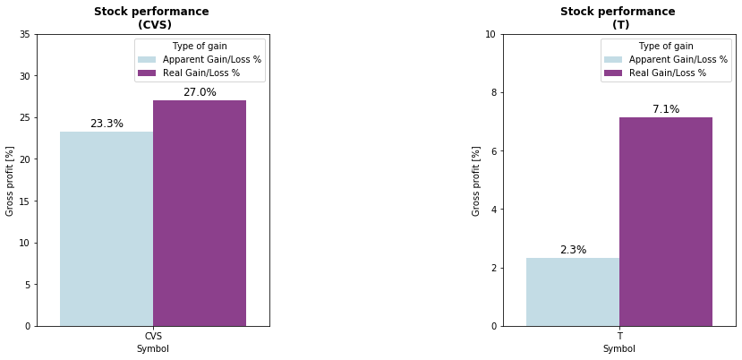

```python
fig, axes = plt.subplots(1, 2, figsize=(14, 6))
fig.subplots_adjust(wspace=1)
#subplot 1
bp = sns.barplot(ax=axes[0],x='Symbol', y='Gross profit [%]', hue='Type of gain',
                 palette=["lightblue", "purple"], data=gainsdf[gainsdf['Symbol']== 'CVS'], alpha =0.8)
bp.set_title('Stock performance \n (CVS)',fontweight='bold')
bp.set_ylim([0,35])
for p in bp.patches:
    bp.annotate('{0:.1f}%'.format(p.get_height()),(p.get_x() + p.get_width() / 2., p.get_height()),
                   ha = 'center', va = 'center',xytext = (0, 9),textcoords = 'offset points', size=12)

#subplot 2
bp2 = sns.barplot(ax=axes[1],x='Symbol', y='Gross profit [%]', hue='Type of gain',
                  palette=["lightblue", "purple"], data=gainsdf[gainsdf['Symbol']== 'T'], alpha =0.8)
for p in bp2.patches:
    bp2.annotate('{0:.1f}%'.format(p.get_height()),(p.get_x() + p.get_width() / 2., p.get_height()),
                   ha = 'center', va = 'center',xytext = (0, 9),textcoords = 'offset points', size=12)
bp2.set_title('Stock performance \n (T)',fontweight='bold')
bp2.set_ylim([0,10])
```

As CVS and AT&T are dividend paying stocks, both of their real gains increase when accounting for dividends. This change is more dramatic as the dividend income gets more imporant when compared to the capital gain/stock price change. This is illustrated in the following figures:

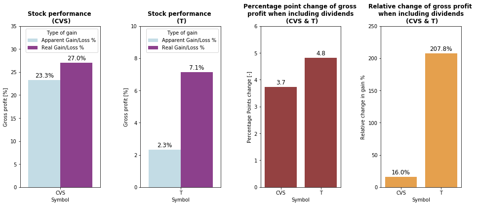

```python
fig, axes = plt.subplots(1, 4, figsize=(16, 6))
fig.subplots_adjust(wspace=.5)

#subplot 1
bp = sns.barplot(ax=axes[0],x='Symbol', y='Gross profit [%]', hue='Type of gain',
                 palette=["lightblue", "purple"], data=gainsdf[gainsdf['Symbol']== 'CVS'], alpha =0.8)
bp.set_title('Stock performance \n (CVS)',fontweight='bold')
bp.set_ylim([0, 35])
for p in bp.patches:
    bp.annotate('{0:.1f}%'.format(p.get_height()),(p.get_x() + p.get_width() / 2., p.get_height()),
                   ha = 'center', va = 'center',xytext = (0, 9),textcoords = 'offset points', size=12)

#subplot 2
bp2 = sns.barplot(ax=axes[1],x='Symbol', y='Gross profit [%]', hue='Type of gain',
                  palette=["lightblue", "purple"], data=gainsdf[gainsdf['Symbol']== 'T'], alpha =0.8)
bp2.set_title('Stock performance \n (T)',fontweight='bold')
bp2.set_ylim([0, 10])
for p in bp2.patches:
    bp2.annotate('{0:.1f}%'.format(p.get_height()),(p.get_x() + p.get_width() / 2., p.get_height()),
                   ha = 'center', va = 'center',xytext = (0, 9),textcoords = 'offset points', size=12)

#subplot 3
bp3 = sns.barplot(ax=axes[2],x='Symbol', y='Percentage Points change [-]',
                  color = 'darkred', data=Holdings[Holdings['Symbol'].str.endswith(('CVS','T'))], alpha =0.8)
bp3.set_title('Percentage point change of gross \n profit when including dividends \n (CVS & T)',fontweight='bold')
bp3.set_ylim([0, 6])
for p in bp3.patches:
    bp3.annotate('{0:.1f}'.format(p.get_height()),(p.get_x() + p.get_width() / 2., p.get_height()),
                   ha = 'center', va = 'center',xytext = (0, 9),textcoords = 'offset points', size=12)

#subplot 4
bp4 = sns.barplot(ax=axes[3],x='Symbol', y='Relative change in gain %',
                  color = 'darkorange', data=Holdings[Holdings['Symbol'].str.endswith(('CVS','T'))], alpha =0.8)
bp4.set(title='Relative change of gross profit \n when including dividends \n (CVS & T)',ylim=(0, 250))
bp4.set_title('Relative change of gross profit \n when including dividends \n (CVS & T)',fontweight='bold')
bp4.set_ylim([0, 250])
for p in bp4.patches:
    bp4.annotate('{0:.1f}%'.format(p.get_height()),(p.get_x() + p.get_width() / 2., p.get_height()),
                   ha = 'center', va = 'center',xytext = (0, 9),textcoords = 'offset points', size=12)
```

### Real Performance: all stocks

Computing the same plots for all the holdings:

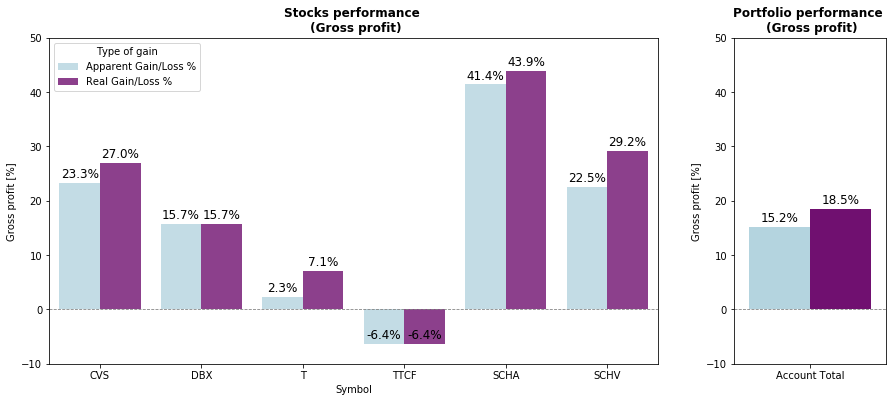

```python
from matplotlib import gridspec
fig = plt.figure(figsize=(15, 6))
gs = gridspec.GridSpec(1, 2, width_ratios=[4, 1])
ax0 = plt.subplot(gs[0])
bp = sns.barplot(ax=ax0,x='Symbol', y='Gross profit [%]', hue='Type of gain',
                 palette=["lightblue", "purple"], data=gainsdf, alpha =0.8)
bp.set_title('Stocks performance \n (Gross profit)',fontweight='bold')
bp.set_ylim([-10,50])
for p in bp.patches:
    bp.annotate('{0:.1f}%'.format(p.get_height()),(p.get_x() + p.get_width() / 2., p.get_height()),
                   ha = 'center', va = 'center',xytext = (0, 9),textcoords = 'offset points', size=12)
ax0.axhline(0, color='grey',ls='--', linewidth=0.8)
ax1 = plt.subplot(gs[1])
bp2 = sns.barplot(ax=ax1,x='Symbol', y='Gross profit [%]', hue='Type of gain',
                  palette=["lightblue", "purple"], data=portdf, alpha =1)
bp2.legend_.remove()
bp2.set_xlabel('')
bp2.set_ylim([-10,50])
bp2.set_title('Portfolio performance \n (Gross profit)',fontweight='bold')
for p in bp2.patches:
    bp2.annotate('{0:.1f}%'.format(p.get_height()),(p.get_x() + p.get_width() / 2., p.get_height()),
                   ha = 'center', va = 'center',xytext = (0, 9),textcoords = 'offset points', size=12)
ax1.axhline(0, color='grey',ls='--', linewidth=0.8)
```

Logically, we can see that non-dividend payment stocks, such as DBX and TTCF, are not affected by this calculation. This is explicity seen in the following plots, with a 0% variation of their absolute/relative change when accounting for dividends:

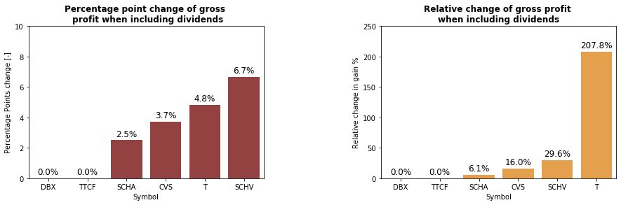

```python
fig, axes = plt.subplots(1, 2, figsize=(15, 4))
fig.subplots_adjust(wspace=.5)
dfplot = Holdings[0:6].sort_values(['Percentage Points change [-]']).reset_index(drop=True)
bp = sns.barplot(ax=axes[0],x='Symbol', y='Percentage Points change [-]', color = 'darkred', data=dfplot, alpha =0.8)
bp.set_title('Percentage point change of gross \n profit when including dividends',fontweight='bold')
bp.set_ylim([0, 10])
for p in bp.patches:
    bp.annotate('{0:.1f}%'.format(p.get_height()),(p.get_x() + p.get_width() / 2., p.get_height()),
                   ha = 'center', va = 'center',xytext = (0, 9),textcoords = 'offset points', size=12)
dfplot = Holdings[0:6].sort_values(['Relative change in gain %']).reset_index(drop=True)
bp2 = sns.barplot(ax=axes[1],x='Symbol', y='Relative change in gain %', color = 'darkorange', data=dfplot, alpha =0.8)
bp2.set(title='Relative change of gross profit when including dividends',ylim=(0, 250))
bp2.set_title('Relative change of gross profit \nwhen including dividends',fontweight='bold')
bp2.set_ylim([0, 250])
for p in bp2.patches:
    bp2.annotate('{0:.1f}%'.format(p.get_height()),(p.get_x() + p.get_width() / 2., p.get_height()),
                   ha = 'center', va = 'center',xytext = (0, 9),textcoords = 'offset points', size=12)
```

Lastly, let's depict a scatter plot to visually check both the gross profit and stock size inside the portfolio:

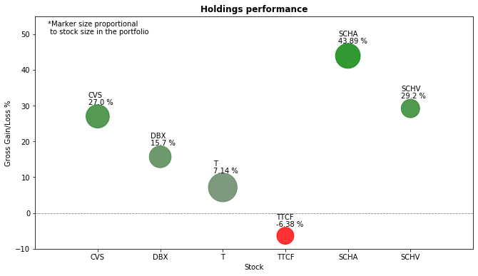

```python
import matplotlib.colors as col
cmapp = col.LinearSegmentedColormap.from_list("", [(0,"red"),(0.001,"grey"),(1,"green")])
dfplot = Holdings[:-2]
f, ax = plt.subplots(figsize=(11, 6))
plt.scatter(dfplot['Symbol'], dfplot['Real Gain/Loss %'], s=dfplot['% Of Account']*80,
            c =dfplot['Real Gain/Loss %'], cmap =cmapp,  alpha=0.8)
#plt.xticks(rotation = 270)
for i, txt in enumerate(dfplot['Symbol']):
    plt.annotate(txt, (i-0.15, dfplot['Real Gain/Loss %'].tolist()[i]+ 4+ dfplot['% Of Account'].tolist()[i]*0.1))
    plt.annotate('{} %'.format(dfplot['Real Gain/Loss %'].tolist()[i]),
                 (i-.15,dfplot['Real Gain/Loss %'].tolist()[i]+ 2+dfplot['% Of Account'].tolist()[i]*0.1))

plt.annotate('*Marker size proportional \n to stock size in the portfolio', (-0.8,50))
ax.axhline(0, color='grey',ls='--', linewidth=0.8)
ax.set_ylabel('Gross Gain/Loss %')
ax.set_xlabel('Stock')
ax.set_xlim([-1,6])
ax.set_ylim([-10,55])
ax.set_title('Holdings performance',fontweight='bold')
plt.show()
```

### Real Performance: overall portfolio

Let's check how the overall portfolio performance is affected when accounting for dividends payments:

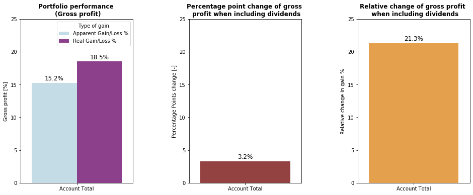

```python
fig, axes = plt.subplots(1, 3, figsize=(16, 6))
fig.subplots_adjust(wspace=.5)
bp = sns.barplot(ax=axes[0],x='Symbol', y='Gross profit [%]', hue='Type of gain',
                 palette=["lightblue", "purple"], data=portdf, alpha =0.8)

bp.set_xlabel('')
bp.set_ylim([0,25])
bp.set_title('Portfolio performance \n (Gross profit)',fontweight='bold')
for p in bp.patches:
    bp.annotate('{0:.1f}%'.format(p.get_height()),(p.get_x() + p.get_width() / 2., p.get_height()),
                   ha = 'center', va = 'center',xytext = (0, 9),textcoords = 'offset points', size=12)
dfplot = Holdings[7:].sort_values(['Percentage Points change [-]']).reset_index(drop=True)

bp2 = sns.barplot(ax=axes[1],x='Symbol', y='Percentage Points change [-]', color = 'darkred', data=dfplot, alpha =0.8)

for p in bp2.patches:
    bp2.annotate('{0:.1f}%'.format(p.get_height()),(p.get_x() + p.get_width() / 2., p.get_height()),
                   ha = 'center', va = 'center',xytext = (0, 9),textcoords = 'offset points', size=12)
bp2.set_xlabel('')
bp2.set_ylim([0,25])
bp2.set_title('Percentage point change of gross \n profit when including dividends',fontweight='bold')

dfplot = Holdings[7:].sort_values(['Relative change in gain %']).reset_index(drop=True)

bp2 = sns.barplot(ax=axes[2],x='Symbol', y='Relative change in gain %', color = 'darkorange', data=dfplot, alpha =0.8)

for p in bp2.patches:
    bp2.annotate('{0:.1f}%'.format(p.get_height()),(p.get_x() + p.get_width() / 2., p.get_height()),
                   ha = 'center', va = 'center',xytext = (0, 9),textcoords = 'offset points', size=12)
bp2.set_xlabel('')
bp2.set_ylim([0,25])
bp2.set_title('Relative change of gross profit \n when including dividends',fontweight='bold')
```

**Accounting for dividends, the gross profit has a relative increase of 21.3% in gains (3.2/15.2).**

# Overview: Real perfomance.

Finally, the following plots summarize the ultimate objective of this notebook: the real performance of each stock and the overall portfolio

```
[]
```

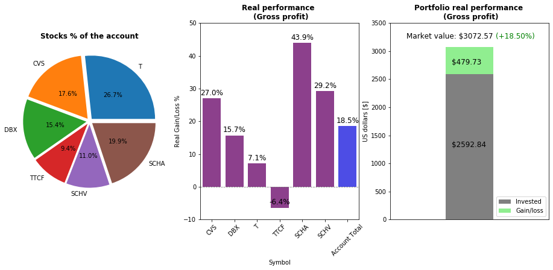

```python
fig, axes = plt.subplots(1, 3, figsize=(16, 6))


labels = pos['Symbol'][:-2]
pie= axes[0].pie(x=pos['% Of Account'][:-2], autopct="%.1f%%", explode=[0.05]*6, labels=labels, pctdistance=0.5)
axes[0].set_title('Stocks % of the account',fontweight='bold')

dfplot = Holdings.loc[Holdings['Symbol'] != 'Cash & Cash Investments']
clrs = ['blue' if (x== 'Account Total') else 'purple' for x in dfplot['Symbol'] ]
bp = sns.barplot(ax=axes[1],x='Symbol', y='Real Gain/Loss %', palette = clrs, data=dfplot, alpha =0.8)
bp.set(title='Stocks performance \n (Gross profit)',ylim=(-10, 50))
axes[1].set_title('Real performance \n (Gross profit)',fontweight='bold')
for p in bp.patches:
    bp.annotate('{0:.1f}%'.format(p.get_height()),(p.get_x() + p.get_width() / 2., p.get_height()),
                   ha = 'center', va = 'center',xytext = (0, 9),textcoords = 'offset points', size=12)
axes[1].axhline(0, color='grey',ls='--', linewidth=0.8)

axes[1].set_xticklabels(dfplot['Symbol'], rotation=45)

Invested = Holdings['Real Cost Basis'][7]
Gain = Holdings['Real Gain/Loss $'][7]
Market_value = Invested + Gain

p1=axes[2].bar(1,Invested,color = 'grey',label = 'Invested',width=0.6)
p2=axes[2].bar(1,Gain,color='lightgreen',bottom=Invested,label = 'Gain/loss',width=0.6)
axes[2].legend(loc='lower right')
axes[2].set_xlim([0,2])
axes[2].set_ylim([0,3500])
plt.annotate('${0:.2f}'.format(Invested),(0.77,Invested*.5),size = 12)
plt.annotate('${0:.2f}'.format(Gain),(0.77,Market_value*.9),size = 12)
plt.annotate('Market value: ${0:.2f}'.format(Market_value),(0.2,Market_value*1.05),size = 12)
plt.annotate('(+{0:.2f}%)'.format(Holdings['Real Gain/Loss %'][7]),(1.33,Market_value*1.05),size = 12, c='green')
axes[2].set_title('Portfolio real performance \n (Gross profit)',fontweight='bold')
axes[2].set_ylabel('US dollars [$]')
axes[2].set_xticks([])
```